# Ford GOBike System

## I choose ford GoBike system data-set , which includes information about individual rides made in a bike-sharing system covering the greater San Francisco Bay area.

**D- Data Visualization**

**2- Bivariate**

**2.2- relation between member_age and bike share for all trip**

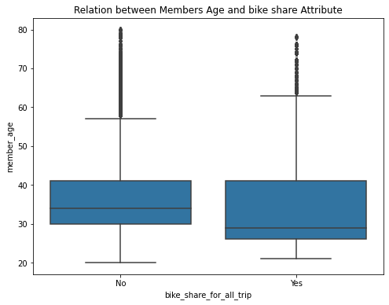

members who share have less median age(less than 30), thats mean youth member share more than other

**2.10- relation between start day and trip duration**

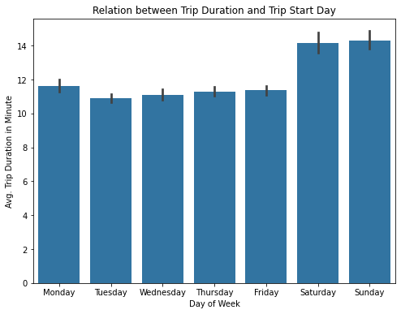

weekend have greatest number of minutes per trip , so member prefered making trips in weekend.

**2.11- relation between start hour and Trip Duration**

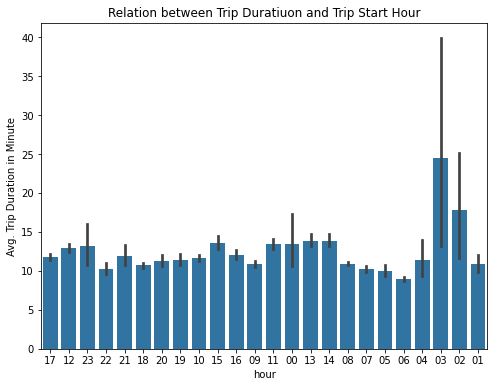

**3- Multivariate Visulaization:**

**3.1- Relation between average duration per trip and start day , with user type**

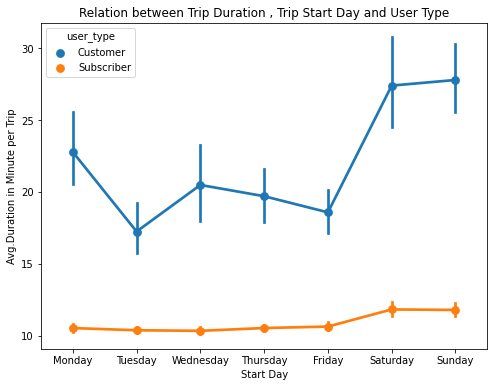

Weekend effect , as we see in sunday and saturday the greatest number of minutes per trip , and customer members have largest minutes than subscriber in weekend and all the week

**3.2- relation between Trrp Duration ,Members Age and user type**

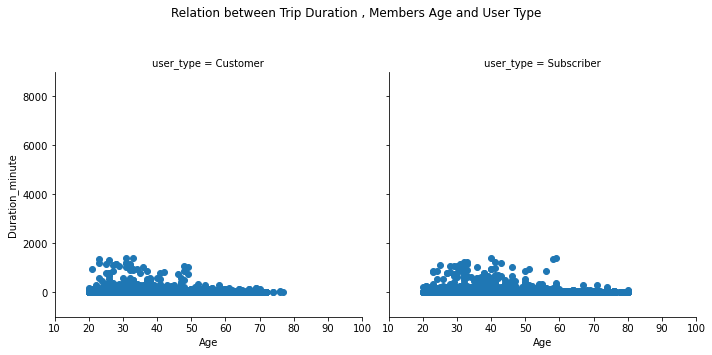